# Project-6

Hannes Gubler

28 May, 2023

# 1 Introduction

The COVID-19 pandemic has had a huge impact on countries worldwide, including the United States. Therefore it is crucial to analyze the underlying patterns of the pandemic to be better prepared for similar scenarios in the future.

In this report, we will work with daily Covid deaths data across all states of the US. The data is from USAFacts and can be downloaded on their [website](https://usafacts.org/visualizations/coronavirus-covid-19-spread-map). We will analyze the data using Principal Component Analysis (PCA), which is a popular technique to examine data with a high number of dimensions (in our case the dimension of our data is the number of days in between 22.01.2020 and 29.04.2023, hence 1194 dimensions). After performing the PCA, we will interpret the first three principal components as well as the low dimensional plot, which displays the data in the first two principal components.

# 2 Data Preparation

Our data contains the daily cumulative number of Covid deaths for each state (observations in rows). We will apply PCA in Section (3) to the cumulative death numbers, however often display daily Covid deaths in our plots for better visual interpretability.

For our analysis, we use the following state abbreviations.

- Alabama: AL
- Alaska: AK
- Arizona: AZ
- Arkansas: AR
- California: CA
- Colorado: CO
- Connecticut: CT
- Delaware: DE
- Florida: FL
- Georgia: GA
- Hawaii: HI
- Idaho: ID
- Illinois: IL
- Indiana: IN
- Iowa: IA
- Kansas: KS
- Kentucky: KY
- Louisiana: LA
- Maine: ME
- Maryland: MD
- Massachusetts: MA
- Michigan: MI
- Minnesota: MN
- Mississippi: MS
- Missouri: MO
- Montana: MT
- Nebraska: NE
- Nevada: NV
- New Hampshire: NH
- New Jersey: NJ
- New Mexico: NM
- New York: NY
- North Carolina: NC
- North Dakota: ND
- Ohio: OH
- Oklahoma: OK
- Oregon: OR
- Pennsylvania: PA
- Rhode Island: RI
- South Carolina: SC
- South Dakota: SD
- Tennessee: TN
- Texas: TX
- Utah: UT
- Vermont: VT
- Virginia: VA
- Washington: WA
- West Virginia: WV
- Wisconsin: WI
- Wyoming: WY

In Figure (2.1) we plot the total number of Covid deaths in the US per day, which we get from summing up all state deaths and then differencing the cumulative data to get the daily death cases.

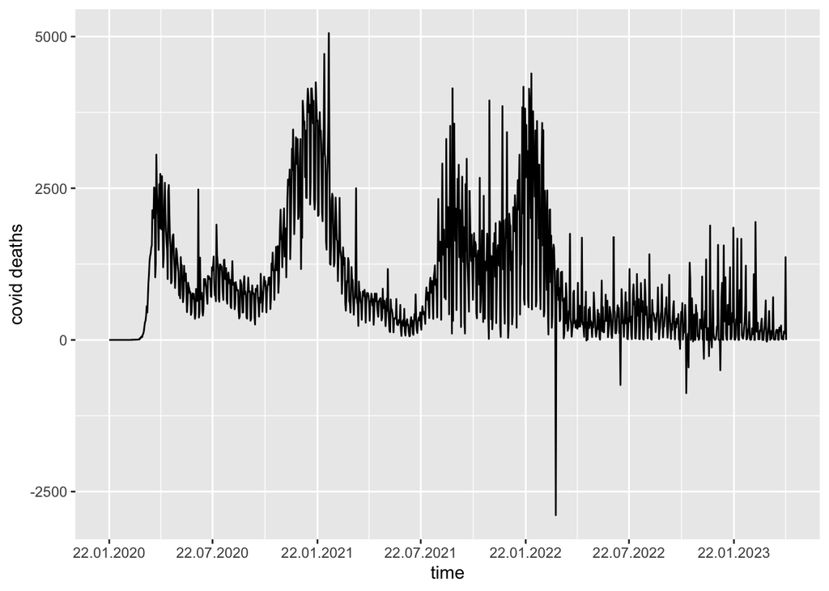

Figure 2.1: Daily Covid deaths in the US from 22.01.2020 until 29.04.2023.

We observe very non-smooth data and some negative values (indicating a negative number of Covid deaths per day which is certainly not possible). This phenomenon occurs because, when counting the Covid deaths over time, certain death cases from a particular day may be subtracted due to counters believing they had overcounted on previous days.

To tackle this issue we apply smoothing to our (cumulative) data using Nadarya-Watson kernel regression with a Gaussian kernel and bandwidth 15 (where the days are numerated as integers from 1 to 1194, where 1194 is the total number of days in our data). We apply smoothing to each state separately.

In Figure (2.2), we replicate the same plot as in Figure (2.1) to review our smoothing results.

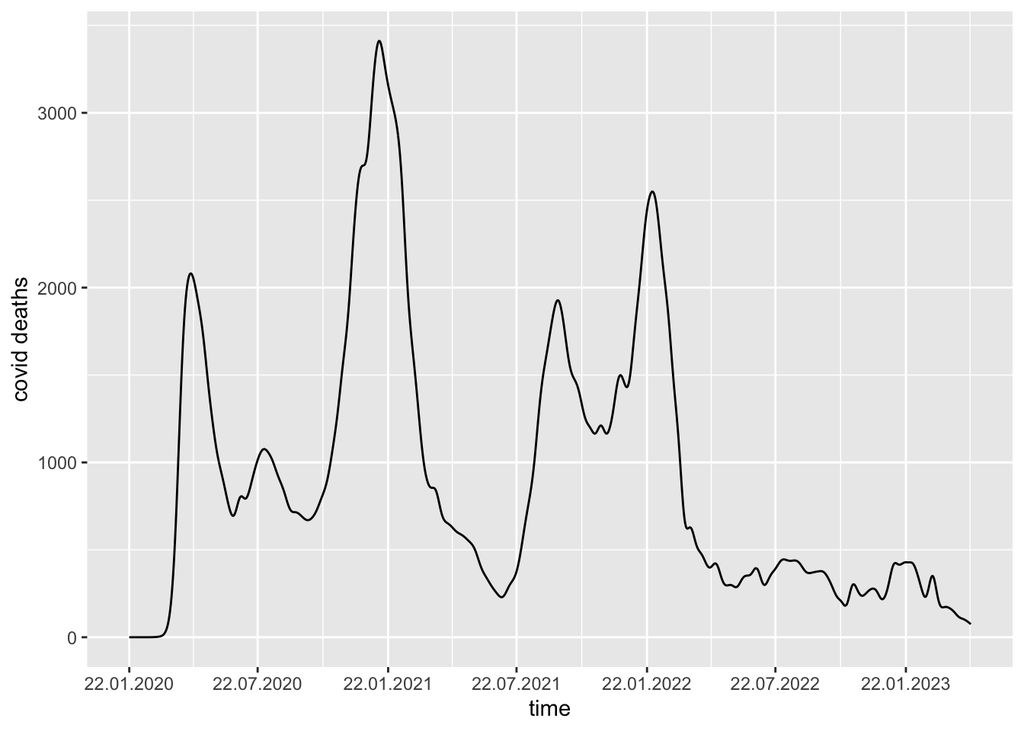

Figure 2.2: Smoothed daily Covid deaths in the US from 22.01.2020 until 29.04.2023.

The smoothed data already looks better and we got rid of negative values. So from now on we work with the smoothed values for the Covid death numbers.

A further preprocessing step, to have more comparable death cases between the states, is to divide all observations from a state by its total population on 01.07.2022, taken from [Wikipedia](https://en.wikipedia.org/wiki/List_of_U.S._states_and_territories_by_population). Therefore, as we work with cumulative numbers, our data contains now the cumulative number of Covid deaths per capita for each state from 22.01.2020 until 29.04.2023, displayed in Figure (2.3).

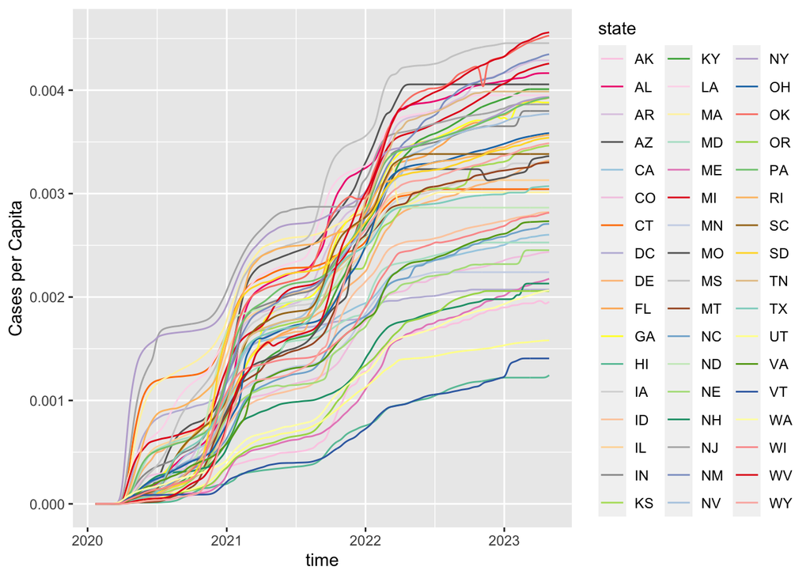

Figure 2.3: Cumulative Covid deaths per capita by states.

## 2.1 Registration

For our PCA, we decide to focus on a shorter time frame than the approximately three years we have in our data. By dedicating our analysis to a shorter time frame, we hope to capture more of the variability in the data by only the first few principal components as our data contains less dimensions in that case. So in our further analysis, we only consider the first Covid wave in the US.

In order to have a more comparable first wave across the different states, we align the starting dates. As the first Covid wave did not spread out at the same time in each state, we define the individual beginning of the first wave in each state to be the point where we have one death per one million inhabitants in that state. To capture only the first wave in each state, we consider the first 75 days after the individual starting dates. In Figure (2.4) we verify that we more or less captured the first Covid wave for each state by this procedure.

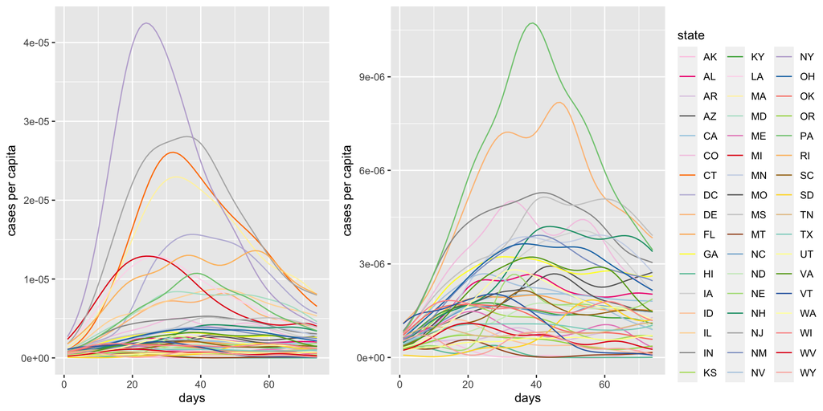

Figure 2.4: Covid deaths per capita for all US states during the first 75 days after a state hits the one death per million inhabitants mark the first time. In the right plot the ten states with the highest numbers during the above described period where excluded to better analyze the states with lower numbers.

We observe that our time registration more or less captured the first wave for each state and therefore we proceed with this data.

In our PCA we will analyze the cumulative death numbers per capita from the data displayed in Figure (2.4) (Cumulative death numbers per capita during the first Covid wave). To have the data more spread out, we take the logarithm of the cumulative death numbers per capita as a last preprocessing step before we perform the PCA.

# 3 Principal Component Analysis

In this section we apply PCA to the data we prepared in the section before, that is the logarithm of the cumulative death numbers per capita during the first Covid wave for each state. In Figure (3.1) we plot the first three principal components as well the percentages of variability retained.

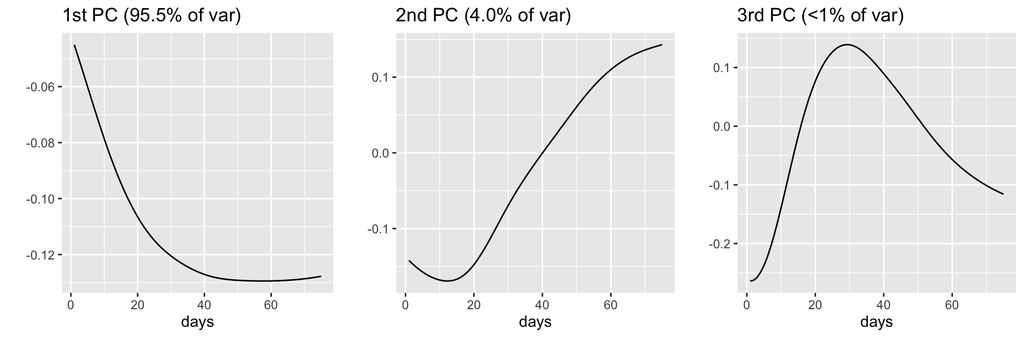

Figure 3.1: First three principal components of logged cumulative death numbers per capita during the first wave of Covid (where one state is one observation).

First note that the percentages of variability retained for the first component is very high (95.5%), so the first principal component already explains a big part of the variability in the data. Such a high number is possible since we only looked at a rather short time frame (75 days) instead of the full data.

## 3.1 Low-Dimensional Plot

In PCA, the low-dimensional plot is the visualization of the data in a reduced dimensional space. In our case, the representation of the data as a linear combination of the first two principal components (which capture already more than 99% of the variability in the data). Furthermore we colorize the observations of our data (states) by the state’s Democratic support in the US presidential election in 2020 (the data can be found on [Wikipedia](https://en.wikipedia.org/wiki/2020_United_States_presidential_election)). In Figure (3.2) we examine the low dimensional plot of our PCA colorized by Democratic support.

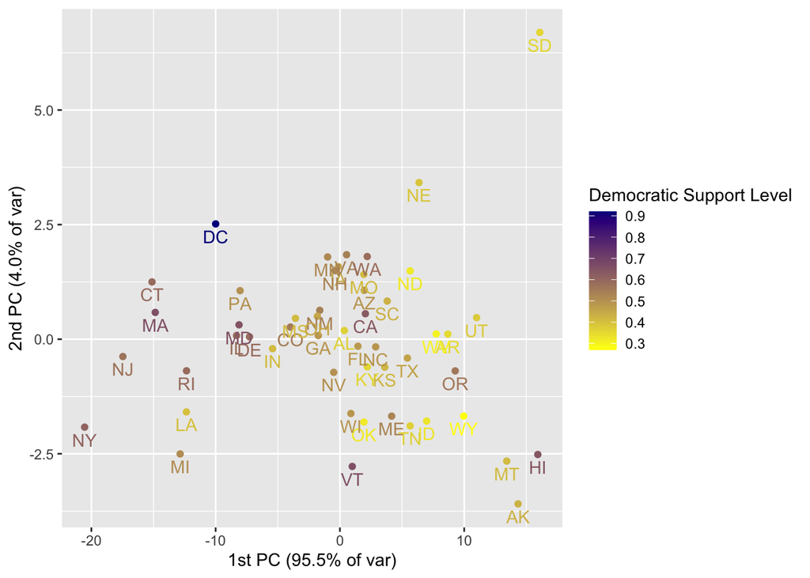

Figure 3.2: Low-dimensional plot of the first two principal components of the data containing the first Covid wave in the US, colorized by Democratic support in the 2020’s US presidential eleciction.

By colorizing the low-dimensional plot of our PCA we detect some grouping in the states that voted more Republic and states that voted more Democratic in the 2020 US presidential election. This suggests that there could be some connection between the development of the first Covid wave in a given state and its political ideology (Republic/Democratic). Especially the first principal component, which captures 95.5% of the variability in the data, shows a clear pattern of Democratic states being more on the left side and Republic states being more on the right side.

# 4 Conclusion

In this report we analyzed data containing the cumulative number of deaths during Covid in the United States, and applied PCA to the first wave of the pandemic. To bring the first Covid wave, that behaved differently in each state, on the same scale we used registration by defining an individual starting point in each state. After that, we kept the data containing the next 75 days after the registered starting point in each state to capture the first wave. Once we performed the PCA, we found that our first two principal components captured almost all variability of the data, which makes it very interesting to look at the low-dimensional plot that represents the data in the first two principal components. In this plot, by colorizing the states with the Democratic support in the 2020 US presidential election, we found a connection between the first Covid wave in the US and the political state ideology. This is an interesting result, but as PCA is just an exploratory tool, a more in depth statistical analysis would be needed to draw definitive conclusions.